# U.S. News National University Ranking Simulations

Using Hanover Ranking Simulator

Jorge Martinez

2020-03-30

# Executive Summary

Ranking simulations show 5 influential factors to increase UH national ranking. In order of greatest impact they include six-year graduation rates, faculty salary, peer score, alumni giving rate, and proportion of classes with fewer than 20 students. `Table 1` below outlines key findings with a baseline simulated rank of 168 (see next section for discussion). Reaching aspirational peer values shows UH can rank as good as 57. With more modest goal setting, UH can improve ranking to 118.

Table 1. Ranking Simulation Summary.  
Increasing our six-year graduation rate to our goal of 70% increases our national rank 64 spots, from 168 to 104.  
Increasing average faculty salary by 5.6% from $95.7K to $101K increases our rank by 7 spots, from 168 to 161. Increasing this value to $111K increases the rank further, from 168 to 158.  
Increasing our peer score from 2.9 to 3.0 improves our rank from 168 to 161. If we improve our peer score to 3.7 like our aspirational peers our rank jumps to 126. See appendix and [this report](https://jxmartinez.com/talk/identifying-institutional-peers/identifying-institutional-peers.pdf) for comparable and aspirational peers.  
Increasing alumni giving by 3 percentage points from 12% to 15% increases our rank by 7 spots. Increasing it to 17% (Texas A&M rate), the rank improves further, from 168 to 158.  
Improving the proportion of classes with less than 20 students to 45% (University of South Florida rate) increases our rank from 168 to 158. Increasing this value two more percentage points boosts ranking to 150.

[output not shown]

# Hanover Ranking Simulator

The Hanover Ranking Simulator offers “what if” simulations allowing institutions to adjust ranking factor values to see where the biggest impact can be made to improve their National University Rankings. `Figure 1` shows a screenshot of what the simulator looks like.

Figure 1. Ranking Simulator Baseline for UH 2020 National Ranking.

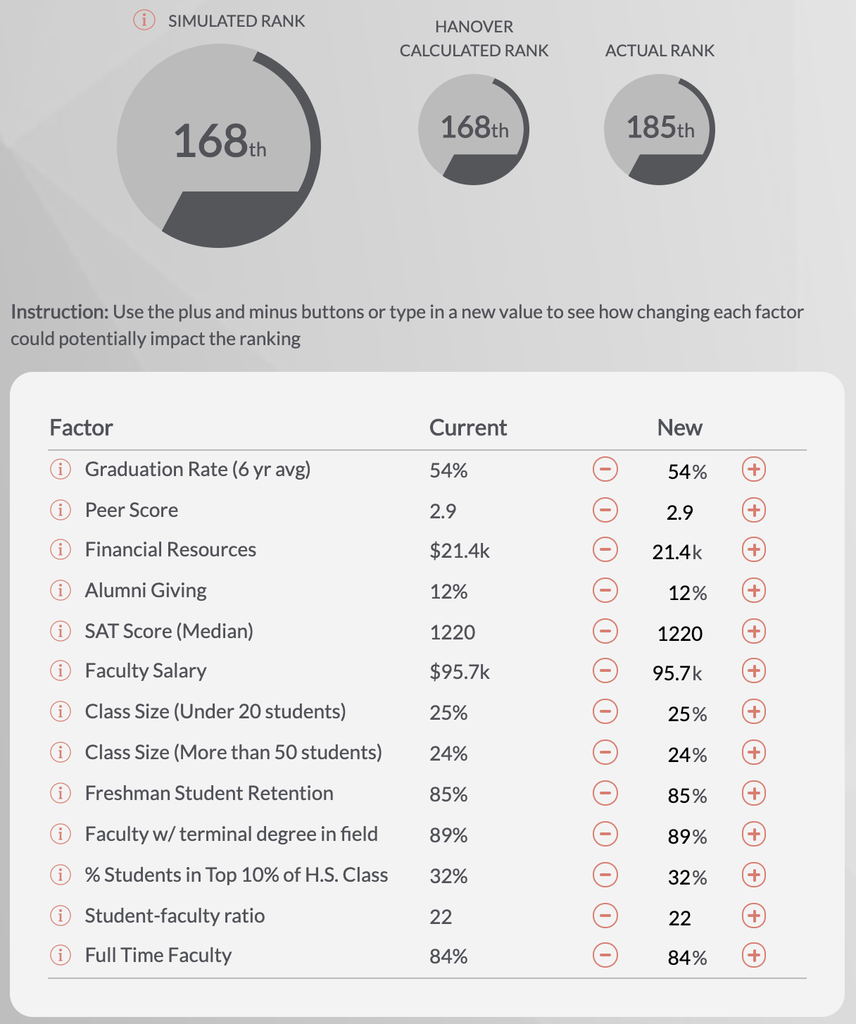

The simulator for the University of Houston starts with a simulated rank of 168. Adjusting the values shows how this rank can change in different scenarios. It is a reconstruction of the data used by U.S. News & World Report (USNWR). An exact reconstruction is not possible because USNWR use proprietary data and methodology not publicly available. This parallel rank is the baseline rank for this analysis.

Actual National Universities Rank for Issue Year 2020 is 185.

# Findings

In this analysis, I recorded the change in rank for every unit change in factors available in the simulator. `Figure 2` graphically represents how UH’s rank changes by each factor. `Table 2` lists the most impactful factors based on the slope of change in rank (dashed-lines in `Figure 2`).

Level of impact is measured by the standardized slope for each factor. More negative values indicate steeper increases in national ranking. Factors are measured in different scales (counts, percents, scores, ratios). I scaled the factors to have a mean of zero and standard deviation one to facilitate comparing different scales.

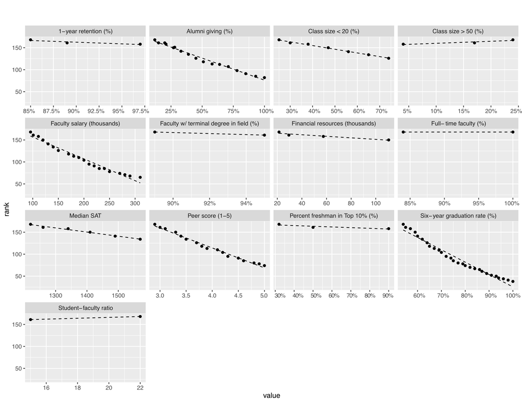

Figure 2. Simulated Rank by Adjusting Each Individual Ranking Factor.

Table 2. Ranking Factors Sorted by Most Influential Increases in Rank.

| Factor | Slope | Std. Slope | Current Value | Max Value | Max Rank |
| --- | --- | --- | --- | --- | --- |
| Six-year graduation rate (%) | -281.10 | -39.34 | 54% | 100% | 38 |
| Faculty salary (thousands) | -0.50 | -32.94 | $95.7K | $310K | 65 |
| Peer score (1-5) | -45.33 | -30.83 | 2.9 | 5 | 74 |
| Alumni giving (%) | -100.20 | -28.47 | 12% | 100% | 82 |
| Class size < 20 (%) | -83.80 | -15.23 | 25% | 74% | 126 |
| Median SAT | -0.09 | -12.73 | 1220 | 1570 | 134 |
| Financial resources (thousands) | -0.18 | -7.08 | $21.4K | $110.5K | 150 |
| Faculty w/ terminal degree in field (%) | -116.70 | -4.95 | 89% | 95% | 161 |
| 1-year retention (%) | -76.79 | -4.69 | 85% | 97% | 158 |
| Percent freshman in Top 10% (%) | -15.62 | -4.64 | 32% | 90% | 158 |
| Class size > 50 (%) | 46.60 | 4.73 | 24% | 4% | 158 |

Each data point in `Figure 2` shows a change in rank by a change in factor value. More data points represent more incremental change. Less data points show less opportunity for change in rank. The dotted line represents the slope or rate of change for these factors. Visually, we see six-year graduation rates make the biggest impact in ranking. If we increase our six-year graduation rate by one percentage point (55%), our rank would jump to 161. If we increase it to 60%, our rank jumps to 141. If we increase our rank to our goal of 70%, our rank would jump to 104 by this factor alone. There are many and large gains in focusing on our six-year graduation rate relative to other factors.

Six-year graduation rates are the most recent 3-year averages. Graduation and retention rates comprise 22% of the overall ranking as of Issue Year 2020. Individually, six-year graduation rates alone make-up 17.6% of the overall rank. Visit [US News 2020 Ranking Methodology](https://www.usnews.com/education/best-colleges/articles/how-us-news-calculated-the-rankings) for more details.

See Appendix for each individual data point.

Faculty salary is the second most impactful factor according to the simulator. If we increase faculty salary from $95.7 thousand to $101 thousand, our rank would increase seven spots from 168 to 161. Increasing average faculty salary another $10 thousand would bump the simulated rank to 158 (see appendix for more values).

Faculty salary/compensation is a component of the Faculty Resources factor (20% of overall rank). Faculty salary by itself makes up 7% of the overall ranking.

Improving our Peer Score is the third most influential factor in improving our ranking. Increasing our peer score from 2.9 to 3.0 increases our rank to 161. Increasing our peer score to 3.4 would increase our simulated rank to 141.

Peer score is 20% of the overall rank.

Alumni giving makes up 5% of the overall rank. Increasing alumni giving from 12% to 15% increases the rank from 168 to 161. If we more than double our giving to 27%, the overall rank could jump 18 spots to 150. Increasing this figure to 39%, or more than triple our current alumni giving, will bump UH’s rank to 135.

Alumni giving is 5% of overall rank.

Percent of class size less than 20 is a component of the class size indicator under Faculty Resources. Increasing the proportion of classes under 20 from 25% to 30% increases the rank from 168 to 161. Nearly doubling this proportion to 47% increases the rank to 150.

The class size indicator is 8% of the overall rank. It belongs to Faculty Resources, which also includes percent of faculty that are full-time, percent faculty with Ph.D., faculty compensation, and student-faculty ratio. All faculty resources together is 20% of overall rank.

The remaining factors are not as influential in increasing our national rank. This can be seen two ways: (1) relatively flat slopes in `Figure 2` and (2) fewer and spread-out data points that indicate a need for a bigger change to see a small return in rank.

Median SAT, financial resources, percent faculty with terminal degree (Ph.D.), 1-year retention rates, percent freshmen in Top 10%, percent of classes greater than 50.

# Adjusting Multiple Values in the Simulator

`Table 3` shows UH’s rank with 2020 values, values selected from different comparison institutions, and more modest values.

See appendix Figures 3 to Figure 8 for comparison institutions.

Table 3. UH Rank by Simulated Values.

| Factor | 2020 Value | Comparison Institutions | Modest Value |
| --- | --- | --- | --- |
| Six-year graduation rate (%) | 54% | 70% | 61% |
| Faculty salary (thousands) | $95.7K | $110K | $100K |
| Peer score (1-5) | 2.9 | 3.7 | 3.1 |
| Alumni giving (%) | 12% | 17% | 15% |
| Class size < 20 (%) | 25% | 45% | 30% |
| Median SAT | 1220 |  |  |
| Financial resources (thousands) | $21.4K |  |  |
| Faculty w/ terminal degree in field (%) | 89% |  |  |
| 1-year retention (%) | 85% |  |  |
| Percent freshman in Top 10% (%) | 32% |  |  |
| Class size > 50 (%) | 24% | 12% |  |
| National Rank | 168 | 57 | 118 |

If we were to reach our six-year graduation rate goal of 70%, increase faculty salary by $14.3 thousand, increase our peer score to 3.7, bump alumni giving to 17%, and increase percent of class size with less than 20 students to 45% like the University of South Florida, UH could have a National Rank of **57**. That’s an increase of 111 rank spots. If we were to set more achievable goals outlined in the modest values column, we could achieve a rank of **118**.

I chose 61% for six-year graduation rate to reflect our current single-cohort graduation rate even though it is not yet reflected in our 3-year average.

# Conclusion

In this analysis, I recommend 5 factors UH can focus towards increasing our National University Rank. I chose these factors based on which showed the greatest potential for increasing our rank using the Hanover Ranking Simulator. They are:

- Six-year graduation rate
- Faculty salary
- Peer score
- Alumni giving rate
- Percent of classes < 20 students

I analyzed how our rank would change if we had values similar to our comparison peers and how our rank would change if we made more achievable goals. I found our rank would be as good as 57 in the best case scenario. I also found our rank would be as good as 118 if we set more modest goals. In the modest scenario, we would increase our ranking by 50 spots.

It is important to remember this analysis is based on the most recent 2020 USNWR National Ranking simulated data. USNWR is a relative ranking system. This means it is susceptible not only to changes in ranking methodology, but as a relative scale our rank is dependent on the number of institutions being ranked. Although we did not under perform between 2019 and 2020 ranking years, our absolute rank dropped because USNWR introduced new and more competitive institutions that were not previously ranked due to a change in the Carnegie Classification System. This analysis is valid for the most recent 2020 rank and it assumes every other institution does not change in their rank position.

[Visit this link](https://www.usnews.com/education/blogs/college-rankings-blog/articles/2019-09-09/what-changed-in-how-the-2020-us-news-best-colleges-rankings-were-calculated) to see the changes between 2019 and 2020. See section titled *Ranking Categories*.

# Appendix

Table 4. UH Rank by Simulated Factor Values.

| Factor | Value | Simulated Rank |
| --- | --- | --- |
| Six-year graduation rate (%) | 0.54 | 168 |
| Six-year graduation rate (%) | 0.55 | 161 |
| Six-year graduation rate (%) | 0.57 | 158 |
| Six-year graduation rate (%) | 0.59 | 150 |
| Six-year graduation rate (%) | 0.60 | 141 |
| Six-year graduation rate (%) | 0.62 | 134 |
| Six-year graduation rate (%) | 0.64 | 126 |
| Six-year graduation rate (%) | 0.65 | 118 |
| Six-year graduation rate (%) | 0.67 | 113 |
| Six-year graduation rate (%) | 0.69 | 109 |
| Six-year graduation rate (%) | 0.70 | 104 |
| Six-year graduation rate (%) | 0.72 | 95 |
| Six-year graduation rate (%) | 0.74 | 91 |
| Six-year graduation rate (%) | 0.75 | 85 |
| Six-year graduation rate (%) | 0.77 | 80 |
| Six-year graduation rate (%) | 0.79 | 78 |
| Six-year graduation rate (%) | 0.80 | 74 |
| Six-year graduation rate (%) | 0.82 | 70 |
| Six-year graduation rate (%) | 0.84 | 67 |
| Six-year graduation rate (%) | 0.86 | 65 |
| Six-year graduation rate (%) | 0.87 | 61 |
| Six-year graduation rate (%) | 0.89 | 56 |
| Six-year graduation rate (%) | 0.91 | 52 |
| Six-year graduation rate (%) | 0.93 | 50 |
| Six-year graduation rate (%) | 0.94 | 46 |
| Six-year graduation rate (%) | 0.96 | 44 |
| Six-year graduation rate (%) | 0.98 | 41 |
| Six-year graduation rate (%) | 1.00 | 38 |
| Peer score (1-5) | 2.90 | 168 |
| Peer score (1-5) | 3.00 | 161 |

[output cut: 84 more lines]

Figure 3. Select Aspirational Peers. Tip: Zoom to see figures.

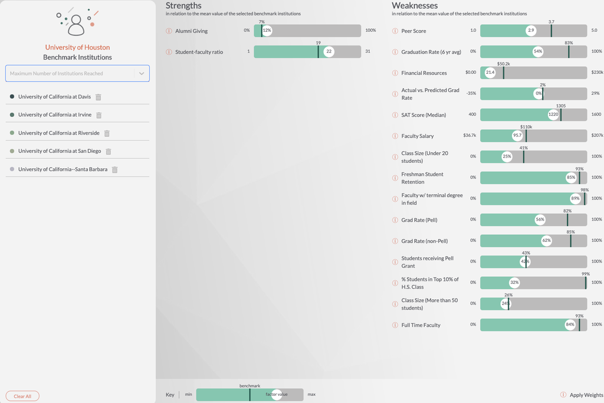

Figure 4. Select Aspirational Peers (cont’d).

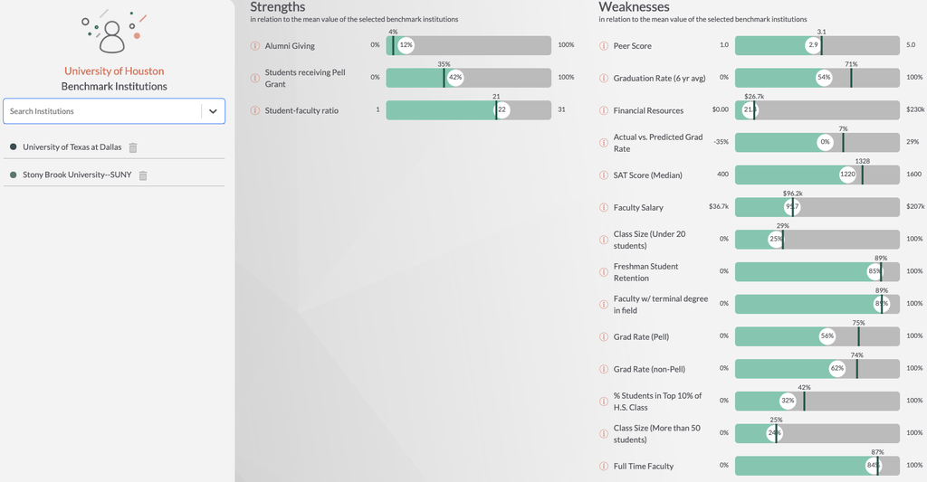

Figure 5. University of Texas and Texas A&M.

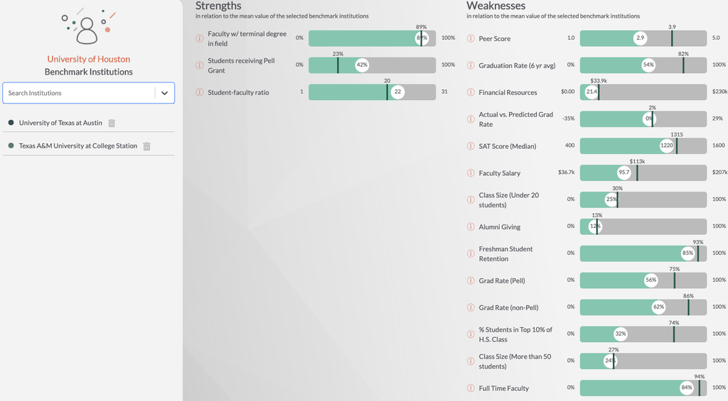

Figure 6. Select Texas Peers.

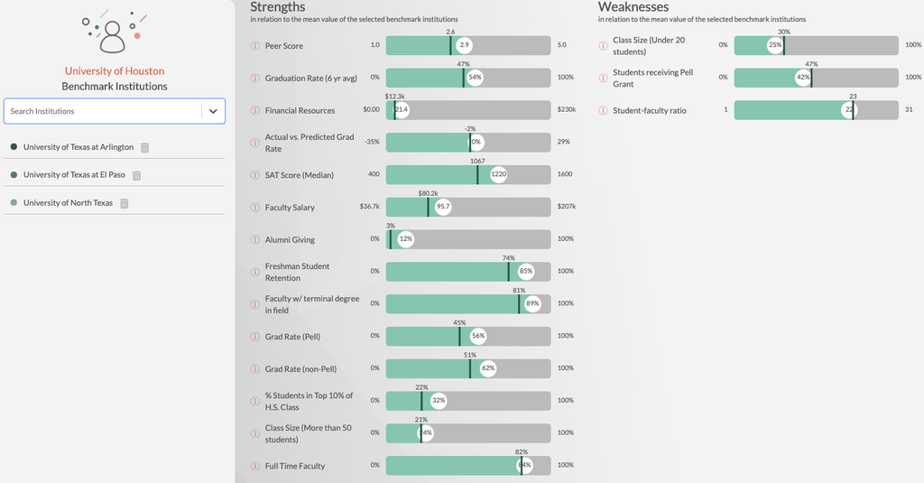

Figure 7. UT-Dallas.

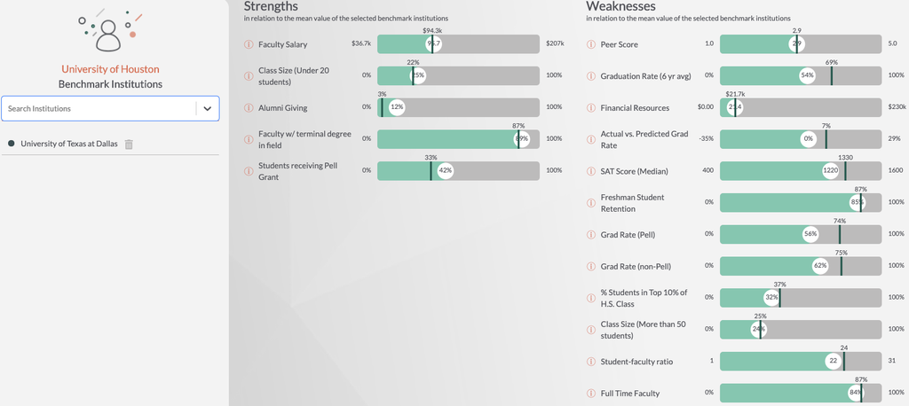

Figure 8. University of South Florida.

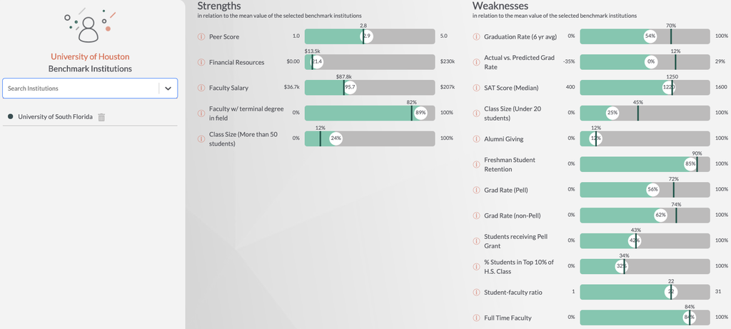